# rExpertQuery Cybertown Training

ATTAINS Team

2025-05-28

## About Expert Query and rExpertQuery

[Expert Query](https://owapps.epa.gov/expertquery/attains/tmdl) empowers users to access surface water quality data from the [Assessment and TMDL Tracking and Implementation System (ATTAINS)](https://www.epa.gov/waterdata/upload-data-resources-registered-attains-usershttps://www.epa.gov/waterdata/upload-data-resources-registered-attains-users) encompassing Assessment decisions (under Clean Water Act Sections 303(d), 305(b), and 106) and Action data like Total Maximum Daily Loads (TMDLs), Advance Restoration Plans (ARPs), and Protection Approaches.

The tool supports querying and downloading data within and across organizations (states or tribes), such as querying all the data within an EPA region or all nutrient TMDLs nationally. It also allows users to download national ATTAINS data extracts.

rExpertQuery takes this a step further as its functions facilitate querying the Expert Query web services and importing the resulting data sets directly in to R for more detailed review and analysis.

It is crucial to be aware of certain complexities inherent in the data and querying process. Users are cautioned against direct comparisons between states due to differences in water quality standards and assessment methodologies.

While Expert Query facilitates data querying, it lacks built-in summary capabilities. Users are encouraged to download and summarize data, but use caution when relying on row counts, as duplicate entries may occur. This complexity arises from multiple tables that have many-to-many relationships. Several examples of summarizing Expert Query data are included in this vignette. These examples use additional packages for data wrangling, mapping, visualizing and other tasks. Future rExpertQuery vignettes and functions may provide additional examples of how to summarize Expert Query data.

## Installation

You must first have R and R Studio installed to use the rExpert Query (see instructions below if needed). rExpert Query is in active development, therefore we highly recommend that you update it and all of its dependency libraries each time you use the package.

You can install and/or update the [rExpertQuery Package](https://github.com/USEPA/rExpertQuery) and all dependencies by running:

```r
# install and load rExpertQuery
if (!"remotes" %in% installed.packages()) {
  install.packages("remotes")
}

remotes::install_github("USEPA/rExpertQuery", ref = "training", dependencies = TRUE, force = TRUE)
```

[output not shown]

```r
library(rExpertQuery)
```

This vignette also requires additional packages which can be installed using the code chunk below:

```r
# # list of additional required packages
#  demo.pkgs <- c("datasets", "data.table", "dplyr", "DT", "ggplot2", "httr", "leaflet", "maps", "plotly", "sf", "usdata", "usmap", "stringi")
#
# # install additional packages not yet installed
#  installed_packages <- demo.pkgs %in% rownames(installed.packages())
#
# if (any(installed_packages == FALSE)) {
#    install.packages(demo.pkgs[!installed_packages])
#  }

# load additional packages for this vignette
library(datasets)
library(data.table)
library(dplyr)
library(DT)
library(ggplot2)
library(httr)
library(leaflet)
library(maps)
library(plotly)
library(sf)
library(usdata)
library(usmap)
library(stringi)
```

As a final setup step, we will turn off scientific notation so that any catchment id numbers from our queries are displayed correctly.

```r
# turn off scientific notation (for catchment ids)
options(scipen = 999)
```

## API Key

Most of the rExpertQuery functions require an API key. Users can obtain their own by using Expert Query’s [API Key Signup Form](https://owapps.epa.gov/expertquery/api-key-signup).

[figure not shown]

To run this vignette, we can use the following test key. Users should obtain their own API key if they will be using rExpertQuery to develop their own workflows.

```r
# load test api  key
testkey <- "53BVce47MQ3KXKibjx35g4ojaDQGh8qWfbdO8cE0"
```

## rExpert Query Functions

1. [EQ_Actions()](https://usepa.github.io/rExpertQuery/reference/EQ_Actions.html) - queries and returns ATTAINS actions data
2. [EQ_ActionsDocuments()](https://usepa.github.io/rExpertQuery/reference/EQ_ActionsDocuments.html) - queries and returns ATTAINS Actions Documents, including a keyword search
3. [EQ_Assessments()](https://usepa.github.io/rExpertQuery/reference/EQ_Assessments.html) - queries and returns ATTAINS Assessments (default is for latest cycle)
4. [EQ_AssessmentUnits()](https://usepa.github.io/rExpertQuery/reference/EQ_AssessmentUnits.html) - queries and returns ATTAINS Assessment Units (default is for Active AUs)
5. [EQ_AUsMLs()](https://usepa.github.io/rExpertQuery/reference/EQ_AUsMLs.html) - queries and returns ATTAINS Assessment Units with Monitoring Location data
6. [EQ_CatchCorr()](https://usepa.github.io/rExpertQuery/reference/EQ_CatchCorr.html) - queries and returns ATTAINS Catchment Correspondence data (memory intensive)
7. [EQ_Sources()](https://usepa.github.io/rExpertQuery/reference/EQ_Sources.html) - queries and returns ATTAINS Sources data
8. [EQ_TMDLs()](https://usepa.github.io/rExpertQuery/reference/EQ_TMDLs.html) - queries and returns ATTAINS TMDL data

These first eight functions are analogous to the data profiles that can be queries through the [Expert Query User Interface](https://owapps.epa.gov/expertquery/attains/).

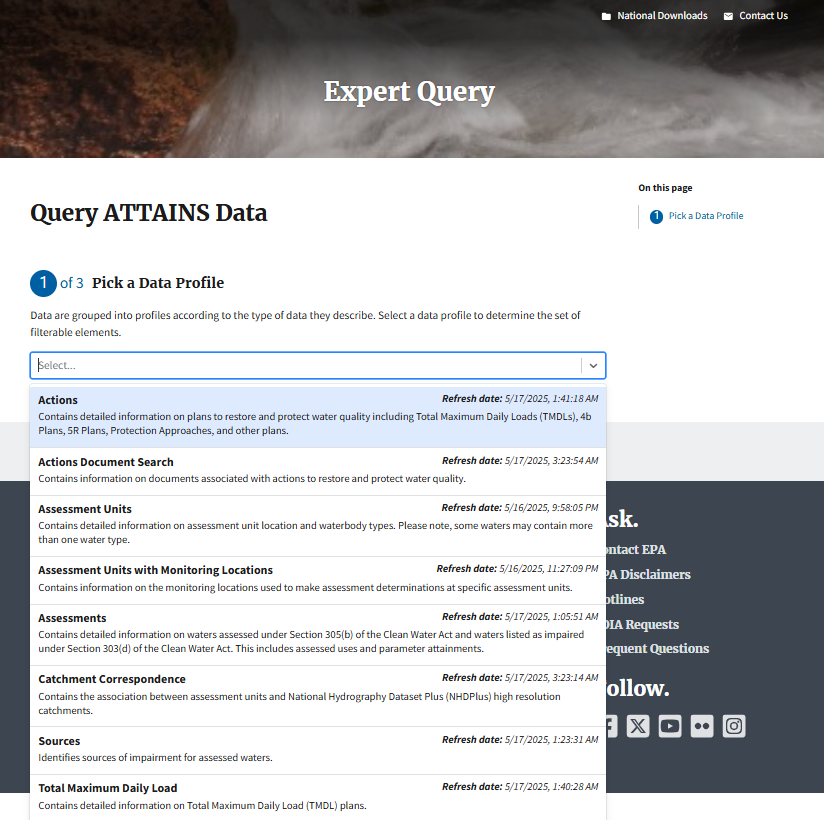

An additional function allows users to download the [Expert Query National Extracts](https://owapps.epa.gov/expertquery/national-downloads) of ATTAINS data which are updated weekly. This function should be used when national data are desired or when a query designed in one of the previous eight functions would exceed the Expert Query web services limit of one millions rows. This function is:

9. [EQ_NationalExtract()](https://usepa.github.io/rExpertQuery/reference/EQ_NationalExtract.html) - returns national extract for Actions, Assessments, Assessment Units, Assessment Units with Monitoring Locations, Catchment Correspondence, Sources, or TMDLS based on user selection

The tenth function relies on [ATTAINS web services](https://www.epa.gov/waterdata/how-access-and-use-attains-web-services) to provide allowable domain values for some rExpertQuery parameters:

10. [EQ_DomainValues()](https://usepa.github.io/rExpertQuery/reference/EQ_DomainValues.html) - returns domain values for some rExpertQuery function params

## Demo Structure

In this session, we will use rExpertQuery functions, along with some common R packages for data wrangling and visualization to answer some commonly asked questions with Expert Query data. Members of the ATTAINS team will be monitoring the chat for questions. If there are many questions regarding a particular function, we may pause at the end of that function’s material to review. Otherwise, questions are welcome at the end of the demo as time permits or via e-mailing the ATTAINS team at attains@epa.gov.

## EQ_NationalExtract

[figure not shown]

1. **What is the most commonly reported impairment nationally?**

   After downloading the national assessments data, we’ll need to filter to include only the latest cycle. Next, we can filter for rows containing parameter causes, and summarize how many times each parameter was listed as a cause of impairment. The additional packages used to answer this question are [dplyr](https://dplyr.tidyverse.org/) (data manipulation) and [DT](https://rstudio.github.io/DT/) (interface to DataTables library).

   ```r
   # import natioanl assessments profile
   assessments.nat <- rExpertQuery::EQ_NationalExtract("assessments")
   ```

   ```
   ## [1] "EQ_NationalExtract: downloading Assessments Profile (Expert Query National Extract). It was last updated on May 23, 2025 at 10:00 PM EDT."
   ## [1] "EQ_NationalExtract: unzipping Assessments Profile (Expert Query National Extract)."
   ## [1] "EQ_NationalExtract: opening Assessments Profile (Expert Query National Extract)."
   ```

   ```r
   # filter for latest assessments
   assessments.nat <- assessments.nat %>%
      dplyr::group_by(organizationId) %>%
       dplyr::slice_max(reportingCycle) %>%
       dplyr::select(-objectId) %>%
       dplyr::distinct() %>%
       dplyr::ungroup()

   # count impairments
   count.impair <- assessments.nat %>%
     # filter to retain only parameter causes
     dplyr::filter(parameterStatus == "Cause") %>%
     # subset data to find unique combinations
     dplyr::select(organizationId, assessmentUnitId, parameterName) %>%
     # remove duplicates
     dplyr::distinct() %>%
     # group by parameterName
     dplyr::group_by(parameterName) %>%
     # count listings for each parameterName
     dplyr::summarise(count = length(assessmentUnitId)) %>%
     # arrane in descending order
     dplyr::arrange(desc(count))

   # create data table of impairment count results
   DT::datatable(count.impair, options = list(pageLength = 10, scrollX = TRUE))
   ```

   |  | parameterName | count |
   | --- | --- | --- |
   | 1 | PATHOGENS | 27323 |
   | 2 | SILTATION | 26599 |
   | 3 | ESCHERICHIA COLI (E. COLI) | 22149 |
   | 4 | PH | 11197 |
   | 5 | METALS | 11124 |
   | 6 | MERCURY | 10019 |
   | 7 | FLOW REGIME MODIFICATION | 9356 |
   | 8 | FECAL COLIFORM | 9149 |
   | 9 | MERCURY - FISH CONSUMPTION ADVISORY | 9123 |
   | 10 | DISSOLVED OXYGEN | 8174 |

   [output cut: 447 more lines]

2. **Which waters are impaired for SELENIUM nationally? Which states contain waters impaired for SELENIUM?**

   Again, we’ll use the national assessments data filtered to the latest cycle. Then we will filter for rows where the parameter is both selenium and listed as a cause. The additional packages used in this step are [dplyr](https://dplyr.tidyverse.org/) and [DT](https://rstudio.github.io/DT/).

   ```r
   # filter assessments data set for
   param.nat <- assessments.nat %>%
     # filter for selenium and cause
     dplyr::filter(parameterName == "SELENIUM" &
                     parameterStatus == "Cause")

   # data table of selenium impairments
   DT::datatable(param.nat, options = list(pageLength = 5, scrollX = TRUE))
   ```

   |  | region | state | organizationType | organizationId | organizationName | waterType | reportingCycle | cycleLastAssessed | assessmentUnitId | assessmentUnitName | assessmentUnitStatus | overallStatus | epaIrCategory | stateIrCategory | useGroup | useName | useClassName | useSupport | useIrCategory | useStateIrCategory | monitoringStartDate | monitoringEndDate | assessmentDate | assessmentTypes | assessmentMethods | assessmentBasis | parameterGroup | parameterName | parameterStatus | … |
   | --- | --- | --- | --- | --- | --- | --- | --- | --- | --- | --- | --- | --- | --- | --- | --- | --- | --- | --- | --- | --- | --- | --- | --- | --- | --- | --- | --- | --- | --- | --- |
   | 1 | 9 | AZ | State | 21ARIZ | Arizona | STREAM | 2024 | 2022 | AZ14070006-001_00 | Colorado River, from GLEN CANYON DAM to LEES FERRY | A | Not Supporting | 5 |  | OTHER_USE | Agricultural Irrigation |  | F | 2 |  |  |  |  |  |  |  | METALS (OTHER THAN MERCURY) | SELENIUM | Cause | … |
   | 2 | 9 | AZ | State | 21ARIZ | Arizona | STREAM | 2024 | 2022 | AZ14070006-001_00 | Colorado River, from GLEN CANYON DAM to LEES FERRY | A | Not Supporting | 5 |  | OTHER_USE | Agricultural Livestock Watering |  | F | 2 |  |  |  |  |  |  |  | METALS (OTHER THAN MERCURY) | SELENIUM | Cause | … |
   | 3 | 9 | AZ | State | 21ARIZ | Arizona | STREAM | 2024 | 2022 | AZ14070006-001_00 | Colorado River, from GLEN CANYON DAM to LEES FERRY | A | Not Supporting | 5 |  | ECOLOGICAL_USE | Aquatic and Wildlife (Coldwater Fishery) |  | N | 5 |  |  |  |  |  |  |  | METALS (OTHER THAN MERCURY) | SELENIUM | Cause | … |
   | 4 | 9 | AZ | State | 21ARIZ | Arizona | STREAM | 2024 | 2022 | AZ14070006-001_00 | Colorado River, from GLEN CANYON DAM to LEES FERRY | A | Not Supporting | 5 |  | RECREATION_USE | Full Body Contact |  | F | 2 |  |  |  |  |  |  |  | METALS (OTHER THAN MERCURY) | SELENIUM | Cause | … |
   | 5 | 9 | AZ | State | 21ARIZ | Arizona | STREAM | 2024 | 2022 | AZ14070006-001_00 | Colorado River, from GLEN CANYON DAM to LEES FERRY | A | Not Supporting | 5 |  | DRINKINGWATER_USE | Domestic Water Source |  | F | 2 |  |  |  |  |  |  |  | METALS (OTHER THAN MERCURY) | SELENIUM | Cause | … |
   | 6 | 9 | AZ | State | 21ARIZ | Arizona | STREAM | 2024 | 2022 | AZ14070006-001_00 | Colorado River, from GLEN CANYON DAM to LEES FERRY | A | Not Supporting | 5 |  | FISHCONSUMPTION_USE | Fish Consumption |  | F | 2 |  |  |  |  |  |  |  | METALS (OTHER THAN MERCURY) | SELENIUM | Cause | … |
   | 7 | 9 | AZ | State | 21ARIZ | Arizona | STREAM | 2024 | 2022 | AZ14070007-123_00 | Paria River, from AZ Border to COLORADO RIVER | A | Not Supporting | 5 |  | ECOLOGICAL_USE | Aquatic and Wildlife (Warmwater Fishery) |  | N | 5 |  |  |  |  |  |  |  | METALS (OTHER THAN MERCURY) | SELENIUM | Cause | … |
   | 8 | 9 | AZ | State | 21ARIZ | Arizona | STREAM | 2024 | 2022 | AZ14070007-123_00 | Paria River, from AZ Border to COLORADO RIVER | A | Not Supporting | 5 |  | RECREATION_USE | Full Body Contact |  | N | 5 |  |  |  |  |  |  |  | METALS (OTHER THAN MERCURY) | SELENIUM | Cause | … |
   | 9 | 9 | AZ | State | 21ARIZ | Arizona | STREAM | 2024 | 2022 | AZ14070007-123_00 | Paria River, from AZ Border to COLORADO RIVER | A | Not Supporting | 5 |  | FISHCONSUMPTION_USE | Fish Consumption |  | F | 2 |  |  |  |  |  |  |  | METALS (OTHER THAN MERCURY) | SELENIUM | Cause | … |
   | 10 | 9 | AZ | State | 21ARIZ | Arizona | RIVER | 2024 | 2024 | AZ15010001-003_00 | COLORADO RIVER | A | Not Supporting | 5 |  | OTHER_USE | Agricultural Irrigation |  | F | 2 |  |  |  |  |  |  |  | METALS (OTHER THAN MERCURY) | SELENIUM | Cause | … |

   [output cut: 1897 more lines]

   Then we can create a list of states that have at least one selenium impairment listed. We can also visualize this information on a map, with states containing selenium impairments filled in blue. To build this map, we first create a data frame with all 50 states and a “SeleniumImpairment” column populated with “yes” or “no” to indicate whether it has any listed selenium impairments.

   In addition to [dplyr](https://dplyr.tidyverse.org/), this code chunk also uses [usdata](https://openintrostat.github.io/usdata/index.html) (US demographic data), [datasets](https://stat.ethz.ch/R-manual/R-devel/library/datasets/html/00Index.html) (collection of data sets for use in R), [usmap](https://usmap.dev/) (US choropleth plotting) and [ggplot2](https://ggplot2.tidyverse.org/) (creating graphics).

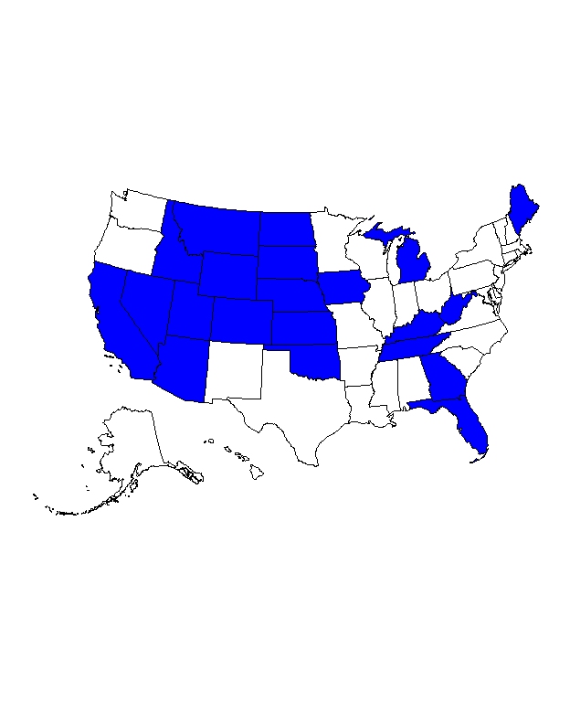

   ```r
   # filter to create df of states that have at least one selenium impairment}
   state.names.sel <- param.nat %>%
     # select state column from filtered df
     dplyr::select(state) %>%
     # retain only distinct values for state
     dplyr::distinct() %>%
     # change state abbreviation to full state name
     dplyr::mutate(state = usdata::abbr2state(state)) %>%
     # create a list from the df
     dplyr::pull()

   # read in a list of all 50 state  names
   state.names <- datasets::state.name

   # create df with of all 50 state names
   sel.map.data <- as.data.frame(state.names) %>%
     # rename state.name column to state
     dplyr::rename(state = state.names) %>%
     # create additional column to indicate if state has recorded selenium impairments ("yes") or not ("no")
     dplyr::mutate(SeleniumImpairment = factor(ifelse(state %in% state.names.sel,
                                               "yes", "no")))

   # create map, specifying data and values
   usmap::plot_usmap(
     regions = "state", data = sel.map.data,
     values = "SeleniumImpairment", color = "black"
   ) +
   # fill states with selenium impairments with blue
     ggplot2::scale_fill_manual(
       values = c(`no` = "white", `yes` = "blue")
     ) +
   # remove legend
     ggplot2::theme(legend.position = "none")
   ```

   In the map above, the states with selenium impairments are blue.
3. **Which waters have a TMDL and are fully supporting nationally?**

   Starting with the filtered data frame of latest cycle assessments, we can filter for Fully Supporting waters with an asssociatedActionType of “TMDL”. Again, we can use a combination of [dplyr](https://dplyr.tidyverse.org/) and [DT](https://rstudio.github.io/DT/), for data manipulation and creating a data table, respectively.

   ```r
   # filter national assessments to includ only Fully Supporting w/ TMDL
   tmdl.fs <- assessments.nat %>%
     dplyr::filter(overallStatus == "Fully Supporting",
                   associatedActionType == "TMDL"
                   ) %>%
     # select columns to review
     dplyr::select(organizationId, state, assessmentUnitId, assessmentUnitName,
                   associatedActionId) %>%
     # group by state and assessmentUnit
     dplyr::group_by(state, assessmentUnitId, assessmentUnitName) %>%
     # create column continaing all actionIds associated with the assessmentUnit
     dplyr::mutate(associatedActionIds = paste(unique(associatedActionId),
                                               collapse = ", ")) %>%
     # remove original associatedActionId column
     dplyr::select(-associatedActionId) %>%
     # retain only distinct rows
     dplyr::distinct()

   # fully supporting waters with tmdls data table
   DT::datatable(tmdl.fs, options = list(pageLength = 5, scrollX = TRUE))
   ```

   |  | organizationId | state | assessmentUnitId | assessmentUnitName | associatedActionIds |
   | --- | --- | --- | --- | --- | --- |
   | 1 | 1VTDECWQ | VT | VT17-02L02 | TURTLE | 10948 |
   | 2 | 1VTDECWQ | VT | VT14-07L02 | TICKLENAKED | 38098 |
   | 3 | 1VTDECWQ | VT | VT11-18L03 | LILY (LONDRY) | 42496 |
   | 4 | 21COL001 | CO | COGUUG30_B | Henson Creek, mainstem | 38980 |
   | 5 | 21COL001 | CO | COARUA03_A | Arkansas River, mainstem | 37706 |
   | 6 | 21COL001 | CO | CORGCB08_B | Kerber Creek, mainstem and all tributaries. Squirrel Creek, mainstem. | 35249 |
   | 7 | 21COL001 | CO | CORGCB08_C | Brewery Creek and Elkhorn Gulch, mainstems | 35249 |
   | 8 | 21COL001 | CO | COGUUN03c_A | Uncompahgre River, mainstem. | 38152 |
   | 9 | 21COL001 | CO | COGUUN03e_B | Uncompahgre River, mainstem. | 38152 |
   | 10 | 21COL001 | CO | COGUUN03e_C | Uncompahgre River, mainstem. | 38152 |

   [output cut: 1068 more lines]

4. **What are the impaired waters (cat 4 and 5 nationally)?**

   The workflow here is similar to the previous question, relying on [dplyr](https://dplyr.tidyverse.org/) and [DT](https://rstudio.github.io/DT/). This time we are retaining a few more columns for inclusion in the data table and are filtering by epaIRCategory for category 4 and 5 waters.

   ```r
   # select subset of columns to include
   imp.waters <- assessments.nat %>%
     dplyr::select(organizationId, organizationName, organizationType,
                   assessmentUnitId, assessmentUnitName, assessmentDate,
                   epaIrCategory, waterType, waterSize, waterSizeUnits) %>%
     # retain only distinct rows
     dplyr::distinct() %>%
     # filter for category 4 and 5 waters
     dplyr::filter(epaIrCategory %in% c("4", "5"))
   ```

   The resulting data frame is large, with 128,870 unique impaired waters nationally. Due to its size, we’ll include a random subset of 250 results in a data table to review during the demo. You can view the full results by viewing the imp.waters df.

   ```r
   # data table with random 250 impaired waters
   DT::datatable(imp.waters %>%
                   dplyr::slice_sample(n = 250),
                 options = list(pageLength = 5, scrollX = TRUE))
   ```

   |  | organizationId | organizationName | organizationType | assessmentUnitId | assessmentUnitName | assessmentDate | epaIrCategory | waterType | waterSize | waterSizeUnits |
   | --- | --- | --- | --- | --- | --- | --- | --- | --- | --- | --- |
   | 1 | IDEQ | Idaho | State | ID17040219SK017_02 | North Fork Big Wood River - source to mouth | 2023/01/04 | 5 | RIVER | 38.7 | Miles |
   | 2 | WVDEP | West Virginia | State | WV-KU-62-AL_01 | Taylor Branch |  | 5 | STREAM/CREEK/RIVER | 1.42 | Miles |
   | 3 | 21PA | Pennsylvania | State | PA-SCR-123860471 | Garretts Run-123860471 |  | 5 | STREAM/CREEK/RIVER | 0.0789 | Miles |
   | 4 | 21PA | Pennsylvania | State | PA-SCR-26175768 | Unnamed Tributary to Little Bush Kill-26175768 |  | 5 | STREAM/CREEK/RIVER | 0.2001 | Miles |
   | 5 | MNPCA | Minnesota | State | MN07010202-613 | Unnamed creek |  | 5 | STREAM | 1.91 | Miles |
   | 6 | 21PA | Pennsylvania | State | PA-SCR-54970585 | Unnamed Tributary to South Branch Middle Creek-54970585 |  | 5 | STREAM/CREEK/RIVER | 0.6941 | Miles |
   | 7 | 21NJDEP1 | New Jersey | State | NJ02030104010030-01 | Upper NY Bay / Kill Van Kull (74d07m30s) |  | 5 | ESTUARY | 6.47 | Square Miles |
   | 8 | 21PA | Pennsylvania | State | PA-SCR-69920077 | Casselman River-69920077 |  | 5 | STREAM/CREEK/RIVER | 0.0087 | Miles |
   | 9 | 21PA | Pennsylvania | State | PA-SCR-43487589 | Susquehanna River-43487589 |  | 5 | STREAM/CREEK/RIVER | 0.0441 | Miles |
   | 10 | 21VASWCB | Virginia | State | VAW-L38R_ROA02A98 | Roanoke (Staunton) River | 2020/02/12 | 5 | RIVER | 12.5 | Miles |

   [output cut: 240 more lines]

5. **Which organizations have included any information about monitoringLocations in ATTAINS? Which of these organizations have included any monitoringLocationDataLinks?**

   To answer this question, we’ll need to import a new national extract. As we are curious about monitoringLocations and monitoringLocationDataLinks, we will want to start with the Assessment Units with Monitoring Locations data set. The param value for this in EQ_NationalExtract is “au_mls”. Additional packages needed are [dplyr](https://dplyr.tidyverse.org/) and [DT](https://rstudio.github.io/DT/). We’ll use some additional options in [DT](https://rstudio.github.io/DT/) to highlight useful rows in the final data table.

   ```r
   # import national extract for assessment units/monitoring locations
   nat.ausmls <- rExpertQuery::EQ_NationalExtract("au_mls")
   ```

The next step is to filter the data frame and retain only rows that contain a value for monitoringLocationId. The resulting data frame, called “filtered.mls” will allow us to determine (1) which organizations have included monitoringLocationIdentifiers and (2) which organizations have included monitoringLocationDataLinks.

To find the organizations with monitoringLocationIdentifiers, we will select only the rows organizationId, organizationName, and organizationType and retain the unique rows.

To find the organizations with monitoringLocationIdentifiers, we will apply an additional filter and keep only rows that have a value in the monitoringLocationDataLink column. Then select only the rows organizationId, organizationName, and organizationType and retain the unique rows.

```r
# filter for rows that contain monitoringLocationIds
filtered.mls <- nat.ausmls %>%
  dplyr::filter(monitoringLocationId != "",
                !is.na(monitoringLocationId))

# start with data set filtered to include only rows with MonitoringLocationIds
orgs.mls <- filtered.mls %>%
  # select columns to describe orgs
  dplyr::select(organizationId, organizationName, organizationType) %>%
  dplyr::distinct()


# start with data set filtered to include only rows with MonitoringLocationIds
links.mls <- filtered.mls %>%
  # filter for orgs with monitoringLocationDataLinks
  dplyr::filter(monitoringLocationDataLink != "",
                !is.na(monitoringLocationDataLink)) %>%
  # select columns to describe orgs
  dplyr::select(organizationId, organizationName, organizationType) %>%
  # retain distinct rows
  dplyr::distinct()
```

There are 45 with monitoringLocationId data in ATTAINS. Of these organizations, 5 also contain monitoringLocationDataLinks. We can create a data table to display this information and apply some conditional formatting to highlight the organizations with monitoringLocationIdentifiers in blue and those with monitoringLocationIdentifiers and monitoringLocationDataLinks in orange.

```r
# create data frame summarizing which organizations have monitoringLocationIds and monitoringLocationDataLinks in ATTAINS
ml.table <- nat.ausmls %>%
  # create df of all orgs
  dplyr::select(organizationId, organizationName, organizationType) %>%
  # retain only distinct rows
  dplyr::distinct() %>%
  # add columns indicating whether the org has any data in ATTAINS for monitoringLocationId and monitoringLocationDataLink
  dplyr::mutate(monitoringLocationId = ifelse(organizationId %in%
                                                orgs.mls$organizationId,
                                              "yes", "no"),
                monitoringLocationDataLink = ifelse(organizationId %in%
                                                      links.mls$organizationId,
                                                    "yes", "no"))
# create data table
DT::datatable(ml.table, options = list(pageLength = 10, scrollX = TRUE)) %>%
  # highlight rows for orgs that have monitoringLocationId in blue
  DT::formatStyle(
  "monitoringLocationId", target = "row",
  backgroundColor = styleEqual(c("yes"), c("#66c3c5"))) %>%
  # highlight rows for orgs that also have data for data links in organge
  DT::formatStyle(
  "monitoringLocationDataLink", target = "row",
  backgroundColor = styleEqual(c("yes"), c("#f9b97d")))
```

|  | organizationId | organizationName | organizationType | monitoringLocationId | monitoringLocationDataLink |
| --- | --- | --- | --- | --- | --- |
| 1 | 21PA | Pennsylvania | State | no | no |
| 2 | TDECWR | Tennessee | State | yes | no |
| 3 | SDDENR | South Dakota | State | yes | no |
| 4 | KICKAPOO | Kickapoo Tribe of Oklahoma | Tribe | no | no |
| 5 | PUEBLOOFTESUQUE | Pueblo of Tesuque, New Mexico | Tribe | yes | no |
| 6 | 21HI | Hawaii | State | no | no |
| 7 | 1VTDECWQ | Vermont | State | no | no |
| 8 | MDE_EASP | Maryland | State | no | no |
| 9 | WYDEQ | Wyoming | State | no | no |
| 10 | DELAWARENATION | Delaware Nation, Oklahoma | Tribe | yes | no |

[output cut: 74 more lines]

## EQ_Assessments

[**EQ_Assessments()**](https://usepa.github.io/rExpertQuery/reference/EQ_Assessments.html)queries ATTAINS Assessments data. For many use cases, querying Assessments for a single organization or state is desirable. The next example shows how to query by a single state for the latest cycle. The default for the function is to query for the latest cycle. If you would like to search for an older cycle, you can set the “report_cycle” parameter equal to the desired cycle year in YYYY format.

1. **How many stream miles in Kansas are impaired for primary contact recreation in the latest cycle?**

   First, we can construct our query to return only Primary Contact Recreation Assessments from the latest cycle from Kansas for streams. The remaining steps can be accomplished with [dplyr](https://dplyr.tidyverse.org/) functions to retain unique combinations of assessmentUnitId, assessmentUnitName, waterSize and waterSizeUnits, then summing the waterSize column to find the number of stream miles.

   ```r
   # set up query to search assessments for KS, primary contact recreation use, and stream, default behavior is to query latest report cycle
   ks.imp.streams <- rExpertQuery::EQ_Assessments(statecode = "KS",
                                                  use_name = "Primary Contact Recreation",
                                                  api_key = testkey,
                                                  water_type = "STREAM")

   # calculate total water size
   ks.miles <- ks.imp.streams %>%
     # select required columns
     dplyr::select(assessmentUnitId, assessmentUnitName,
                   waterSize, waterSizeUnits) %>%
     # retain distinct rows
     dplyr::distinct() %>%
     # sum water size
     dplyr::summarize(totalWaterSize = sum(waterSize)) %>%
     dplyr::pull()
   ```

   We start by querying for Montana assessments with zinc as a cause and can use [dplyr](https://dplyr.tidyverse.org/) and [plotly](https://plotly.com/r/) (graphing library) to summarize the results by useName and create a bar plot of the results.

   ```r
   # query MT's latest assessments for zinc as a cause
   MT.impair <- rExpertQuery::EQ_Assessments(statecode = "MT",
                                             api_key = testkey,
                                             param_name = "ZINC",
                                             param_status = "Cause"
                                             )
   ```

   ```
   ## [1] "EQ_Assessments: The current query will return 123 rows."
   ```

   Next we summarize the uses associated with zinc impairments and count the number of unique assessmentUnitIdentifiers for each use to facilitate creating a bar plot.

   ```r
   # summarize by useName
   MT.impair.use <- MT.impair %>%
     dplyr::group_by(useName) %>%
     # count AUIDs by use
     dplyr::summarize(count = length(unique(assessmentUnitId)))
   ```

   There are 3 uses with zinc as a cause in Montana: Agricultural, Aquatic Life, and Drinking Water . As our last step, we’ll create the bar plot.

   ```r
   plotly::plot_ly(data = MT.impair.use,
     x = ~useName,
     y = ~count,
     type = "bar"
   )
   ```

[interactive chart not shown]

3. **Which waters are new to category 5 in the 2024 cycle for Illinois? Which categories did they move from?**

   This is another question that is well suited to using [dplyr](https://dplyr.tidyverse.org/) and [plotly](https://plotly.com/r/) in addition to EQ_Assessments. The query is for category 5 waters from Illinois from the latest reporting cycle. In order to compare reporting cycles, we’ll also need to provide a value for the previous cycle and run the query again, this time for the previous reporting cycle and without specifying the category.

   ```r
   # get cat 5 waters from 2024 assessment cycle
   IL.latest <- rExpertQuery::EQ_Assessments(statecode = "IL",
                               epa_ir_cat = "5",
                                api_key = testkey)

   # select required columns from latest cycle data
   IL.latest <- IL.latest %>%
     dplyr::select(assessmentUnitId, epaIrCategory) %>%
     # retain unique rows
     dplyr::distinct()


   # get all assessments from previous cycle
   IL.previous <- rExpertQuery::EQ_Assessments(statecode = "IL",
                                               report_cycle = 2022,
                                               api_key = testkey)
   ```

   Next we’ll need to filter the previous cycle results to retain only the assessment units that are category 5 waters in the latest cycle. This allows us to combine the latest and previous cycle data frames and filter them to create a data frame which contains only the assessment units that changed from some other category to category 5 from the previous cycle to the latest cycle.

   ```r
   # filter previous cycle to include only cat 5 waters from 2024
   IL.previous <- IL.previous %>%
     # retain only cat 5 waters from latest cycle
     dplyr::filter(assessmentUnitId %in% IL.latest$assessmentUnitId) %>%
     # select auid and category
     dplyr::select(assessmentUnitId, epaIrCategory) %>%
     # rename to indicate previous cycle
     dplyr::rename(epaIrCategory.previous = epaIrCategory)

   # combine latest and previous cycle dfs
   IL.combine <- IL.latest %>%
     dplyr::left_join(IL.previous, dplyr::join_by(assessmentUnitId))

   # create df of the auids that changed to cat 5 in 2024
   IL.changes <- IL.combine %>%
     dplyr::filter(epaIrCategory != epaIrCategory.previous) %>%
     dplyr::distinct()
   ```

   Finally, we can summarize by counting the categories the new category 5s were previously in and create a pie chart to visualize. This example sets up a color palette that mimics the one used in the ATTAINS report module.

   ```r
   # summarize what cats the new cat 5s were in previously
   IL.change.sum <- IL.changes %>%
     dplyr::group_by(epaIrCategory.previous) %>%
     dplyr::summarise(count = dplyr::n_distinct(assessmentUnitId))

   # set color palette for categories
   cat.pal <- c("#9dd49d", "#bee3be", "#c5c5c5", "#f6ce95", "#f9deb8", "#f0bab9",   "#e89895","#4be367","#17b644", "#c5a577")
   # set category names for palette
   cat.pal <-  setNames(cat.pal, c("1", "2", "3", "4A", "4B", "4C", "5", "5A", "5R", "4"))


   # create plotly plot
   plotly::plot_ly() %>%
     # add pipe based IL.change.sum
     plotly::add_pie(data = IL.change.sum, ~count, labels = ~epaIrCategory.previous,
                       marker = list(
                         colors = cat.pal,
                         line = list(color = "white", width = 2)
                       ), type = "pie",
                       hoverinfo = "value", outsidetextfont = list(color = "black"),
                       sort = FALSE
       ) %>%
     # add legend
     plotly::layout(legend = list(orientation = "h",
                                    xanchor = "center",
                                    x = 0.5))
   ```

[interactive chart not shown]

## EQ_AssessmentUnits

[**EQ_AssessmentUnits()**](https://usepa.github.io/rExpertQuery/reference/EQ_AssessmentUnits.html) queries ATTAINS Assessment Units data. The default is to only return “Active” assessment units, but input params can be adjusted to query for “Retired” or “Historical” assessment units in addition to or instead of “Active”.

1. **What are the retired assessment units for Florida?**

   This can be answered with a simple EQ_AssessmentUnits query specifying Florida with an assesment unit status of “Retired” without using functions from any additional packages. For easier review, we’ll create a datatable with [DT](https://rstudio.github.io/DT/).

   ```r
   # search for retired assessment units in Florida
   FL.ret.auids <- rExpertQuery::EQ_AssessmentUnits(statecode = "FL",
                                                   au_status = "Retired",
                                                   api_key = testkey)

## EQ_TMDLs

[**EQ_TMDLs()**](https://usepa.github.io/rExpertQuery/reference/EQ_TMDLs.html) queries ATTAINS TMDL data and can utilize many search parameters.

1. **What are all the TMDLs in HI? How many are there (counted as unique combinations of actionID/pollutant/assessmentUnitId)? How many are associated with each pollutantGroup?**

   To answer this question we’ll use [dplyr](https://dplyr.tidyverse.org/) and [plotly](https://plotly.com/r/). The EQ_TMDLs query is simple, specifying only the state of Hawaii since we want to return all of Hawaii’s TMDLs.

   ```r
   # query for Hawaii TMDLs
   HI.tmdls <- rExpertQuery::EQ_TMDLs(statecode = "HI",
                                      api_key = testkey)
   ```

   The536 rows can be reviewed in the data frame. Keep in mind that if we want to count one TMDL as one unique combination of assessmentUnitIdentifier, pollutant and actionId, we can’t simply count the number of rows as this would lead to double counting as each assessmentUnitIdentifier/pollutant/actionId may be associated with multiple parameters, which means it will be listed more than once. The code chunk below demonstrates one way to determine the number of TMDLs by unique assessmentUnitIdentifier/pollutant/actionId. We can than visualize TMDLs related to each pollutantGroup with a simple bar graph.

   ```r
   # determine the number of tmdls
   HI.count <- HI.tmdls %>%
     # select required columns
     dplyr::select(assessmentUnitId, assessmentUnitName, actionId, actionName, pollutant, pollutantGroup, fiscalYearEstablished, actionAgency, planSummaryLink) %>%
     # retain unique rows
     dplyr::distinct()

   # determine number per group
   HI.sum <- HI.count %>%
     # groupy by pollutantGroup
     dplyr::group_by(pollutantGroup,) %>%
     # count unique auids per pollutantGroup
     dplyr::summarize(count = dplyr::n_distinct(assessmentUnitId)) %>%
     # if pollutantGroup is missing, assing to group named "NULL"
     dplyr::mutate(pollutantGroup = ifelse(is.na(pollutantGroup), "NULL", pollutantGroup))

   # create bar plot
   plotly::plot_ly( data = HI.sum,
     x = ~pollutantGroup,
     y = ~count,
     type = "bar"
   )
   ```

[interactive chart not shown]

   There are 168 TMDLs in Hawaii.
2. **How many TMDL projects (by actionId) were approved so far in FY 2025 in R10?**

   This question can be answered simply with a well crafted query and a single [dplyr](https://dplyr.tidyverse.org/) function. The 2025 fiscal year began on October 1, 2024, so that will be set as the tmdl_start_date parameter along with specifying 10 for the region.

   ```r
   # r10 query for FY 2025 TMDLs
   tmdl.proj <- rExpertQuery::EQ_TMDLs(region = 10,
                                       tmdl_date_start = "2024-10-01",
                                       api_key = testkey)

   # count distinct actionIds
   tmdl.proj.count <- dplyr::n_distinct(tmdl.proj$actionId)
   ```

   ```r
   tmdl.sum <- tmdl.proj %>%
     # select columns
     dplyr::select(region, state, organizationId, organizationName, organizationId,
                   actionId, actionName, assessmentUnitId, pollutant,
                   addressedParameter, tmdlDate, planSummaryLink) %>%
     # retain unique rows
     dplyr::distinct() %>%
     # group by actionId
     dplyr::group_by(actionId) %>%
     # create new columns to address issues with mulitple rows
     dplyr::mutate(assessmentUnitIds = paste(sort(unique(assessmentUnitId)), collapse = ", "
                                             ),
                   pollutants = paste(sort(unique(pollutant)), collapse = ", "),
                   addressedParameters = paste(sort(unique(addressedParameter)), collapse = ", ")) %>% dplyr::select(-assessmentUnitId, -pollutant, -addressedParameter) %>%
     # retain unique rows
     dplyr::distinct()

   # create data table
   DT::datatable(tmdl.sum %>%
                   rExpertQuery::EQ_FormatPlanLinks(), escape = FALSE,
                 options = list(pageLength = 2, scrollX = TRUE))
   ```

   |  | region | state | organizationId | organizationName | actionId | actionName | tmdlDate | planSummaryLink | assessmentUnitIds | pollutants | addressedParameters |
   | --- | --- | --- | --- | --- | --- | --- | --- | --- | --- | --- | --- |
   | 1 | 10 | ID | IDEQ | Idaho | Willow Creek 2024 | Willow Creek Subbasin Total Maximum Daily Loads 2024 Temperature, Nutrients, and Bacteria TMDLs and Five-Year Reviews | 2025-02-06 | https://mywaterway.epa.gov/plan-summary/IDEQ/Willow Creek 2024 | ID17040205SK005_02, ID17040205SK005_05, ID17040205SK008_02, ID17040205SK008_04, ID17040205SK010_02, ID17040205SK011_04, ID17040205SK012_02, ID17040205SK012_03, ID17040205SK013_02, ID17040205SK013_03, … | ESCHERICHIA COLI (E. COLI), PHOSPHORUS, TOTAL, TEMPERATURE | ESCHERICHIA COLI (E. COLI), PHOSPHORUS, TOTAL, TEMPERATURE |
   | 2 | 10 | WA | WA_ECOLOGY | Washington | WA-TMDL-0147 | Spokane and Little Spokane Rivers PCBs TMDLs | 2024-10-28 | https://mywaterway.epa.gov/plan-summary/WA_ECOLOGY/WA-TMDL-0147 | WA17010305000009_001_002, WA17010305000010_001_001, WA17010305000011_001_001, WA17010305000012_001_001, WA17010307000010_001_001, WA17010307000774_001_001, WA17010307009085_001_001, WA17010307009102_0… | POLYCHLORINATED BIPHENYLS (PCBS) | POLYCHLORINATED BIPHENYLS (PCBS) |

## EQ_Actions

[**EQ_Actions()**](https://usepa.github.io/rExpertQuery/reference/EQ_Actions.htmlhttps://usepa.github.io/rExpertQuery/reference/EQ_Actions.html)queries ATTAINS Actions data by a variety of user supplied parameters.

1. **Which actions in Delaware should be included in measures? How many actions (by actionIds) are in this group?**

   We can use [dplyr](https://dplyr.tidyverse.org/) and [DT](https://rstudio.github.io/DT/) with the query results to find the answer and display the relevant actionIds. For the query, we use EQ_Actions to search for Deleware actions with the “in_meas” parameter set to “Yes”. Then we count the distinct actionIds.

   ```r
   # query Actions from Delaware that are included in Measures
   DE.meas <- rExpertQuery::EQ_Actions(statecode = "DE",
                                       in_meas = "Yes",
                                       api_key = testkey)
   ```

   ```
   ## [1] "EQ_Actions: The current query will return 649 rows."
   ```

   ```r
   # count unique actionIds
   DE.count <- dplyr::n_distinct(DE.meas$actionId)
   ```

   There are 480 actionIds that should be included when calculating measures for Delaware. In a similar process to the final TMDL example, we can create a data table with one row per actionId.

   ```r
   # determine unique actionIds
   DE.actids <- DE.meas %>%
     # select columns
     dplyr::select(actionType, actionId, actionName, actionAgency, parameter,
                   completionDate, assessmentUnitId, fiscalYearEstablished,
                   planSummaryLink) %>%
     # retain unique rows
     dplyr::distinct() %>%
     # group by actionId
     dplyr::group_by(actionId) %>%
     # create new columns to address issues with mulitple rows
     dplyr::mutate(parameters = paste(unique(parameter), collapse = ", "),
                   assessmentUnitIds = paste(unique(assessmentUnitId), collapse = ", ")) %>%
     dplyr::select(-parameter, -assessmentUnitId) %>%
     # retain unique rows
     dplyr::distinct()

   DT::datatable(DE.actids %>%
                   rExpertQuery::EQ_FormatPlanLinks(),
                 escape = FALSE,
                 options = list(pageLength = 5, scrollX = TRUE))
   ```

   |  | actionType | actionId | actionName | actionAgency | completionDate | fiscalYearEstablished | planSummaryLink | parameters | assessmentUnitIds |
   | --- | --- | --- | --- | --- | --- | --- | --- | --- | --- |
   | 1 | TMDL | 32082 | APPOQUINMINK - FRESH TIDAL | State | 2006-12-14 | 2007 | https://mywaterway.epa.gov/plan-summary/21DELAWQ/32082 | ENTEROCOCCUS | DE010-001-02_(A) |
   | 2 | TMDL | 31928 | ARMY CREEK -LOWER | State | 2006-12-04 | 2007 | https://mywaterway.epa.gov/plan-summary/21DELAWQ/31928 | ENTEROCOCCUS | DE020-001_(A) |
   | 3 | TMDL | 31812 | BLACKBIRD CREEK -LOWER FROM ROUTE 13 | State | 2006-12-05 | 2007 | https://mywaterway.epa.gov/plan-summary/21DELAWQ/31812 | NUTRIENTS | DE030-001_(A) |
   | 4 | TMDL | 24971 | LOWER BRANDYWINE - MAINSTEM | EPA | 2005-04-08 | 2005 | https://mywaterway.epa.gov/plan-summary/21DELAWQ/24971 | ENTEROCOCCUS | DE040-001_(A) |
   | 5 | TMDL | 32503 | LOWER BRAOD CREEK - COLLINS, CULVERT DITCH, HOLLY DITCH, ROS | State | 2006-12-14 | 2007 | https://mywaterway.epa.gov/plan-summary/21DELAWQ/32503 | ENTEROCOCCUS | DE050-001_(A) |
   | 6 | TMDL | 32509 | TRAP POND BRANCH - SAUNDERS AND THOMPSON BRANCHS | State | 2006-12-14 | 2007 | https://mywaterway.epa.gov/plan-summary/21DELAWQ/32509 | ENTEROCOCCUS | DE050-006-01_(A) |
   | 7 | TMDL | 32513 | RECORDS POND | State | 2006-12-14 | 2007 | https://mywaterway.epa.gov/plan-summary/21DELAWQ/32513 | ENTEROCOCCUS | DE050-L04_(A) |
   | 8 | TMDL | 32515 | TRUSSUM POND | State | 2006-12-14 | 2007 | https://mywaterway.epa.gov/plan-summary/21DELAWQ/32515 | ENTEROCOCCUS | DE050-L06_(A) |
   | 9 | TMDL | 24985 | TRUSSUM POND | State | 1998-12-15 | 1999 | https://mywaterway.epa.gov/plan-summary/21DELAWQ/24985 | DISSOLVED OXYGEN | DE050-L06_(A) |
   | 10 | TMDL | 24986 | TRAP POND | State | 1998-12-15 | 1999 | https://mywaterway.epa.gov/plan-summary/21DELAWQ/24986 | NUTRIENTS | DE050-L07_(A) |

   [output cut: 470 more lines]

2. **How many actions (by actionId) were established in R3 in FY 2024? What was the most common type of action established in R3 in FY 2024?**

   For this query, we will set region equal to 3 and both fisc_year_start and fisc_year_end to 2024. Then use [dplyr](https://dplyr.tidyverse.org/) and [DT](https://rstudio.github.io/DT/) to summarize and display results as in the first EQ_Actions example.

   ```r
   # query for R3 FY2024 actions
   act.fy.24 <- rExpertQuery::EQ_Actions(region = 3,
                                         fisc_year_start = 2024,
                                         fisc_year_end = 2024,
                                         api_key = testkey)

   # count unique actionIds
   n_act.fy.24 <- dplyr::n_distinct(act.fy.24$actionId)
   ```

   There were 7 unique actions by actionId established in R3 in FY 2024. We can create data table with counts for each actionType.

   ```r
   act.fy.24.counts <- act.fy.24 %>%
     # select columns
     dplyr::select(state, organizationId, organizationName,
                     actionId, actionName, actionType) %>%
     # retain unique rows
     dplyr::distinct() %>%
     # group by action type
     dplyr::group_by(actionType) %>%
     # count actionId per each action type
     dplyr::summarize(count = length(unique(actionId)))

   DT::datatable(act.fy.24.counts)
   ```

   |  | actionType | count |
   | --- | --- | --- |
   | 1 | Advance Restoration Plan (ARP) | 1 |
   | 2 | TMDL | 6 |

## EQ_ActionsDocuments

[**EQ_ActionsDocuments()**](https://usepa.github.io/rExpertQuery/reference/EQ_ActionsDocuments.html) queries ATTAINS Actions Documents data with user supplied parameters. One of its unique features is the ability to search the documents themselves by keyword or phrase.

1. **What are all the actions documents that contain the keyword “nutrient”?**

   The only query parameter we will provide is the keyword “nutrient”.

   ```r
   # Actions Documents containing "nutrient"
   nutrient.doc <- rExpertQuery::EQ_ActionsDocuments(doc_query = "nutrient",
                                                     api_key = testkey )
   ```

   This query yields 17,657 results. As well as providing the actionId and documentName for all results, *EQ_Actions()* also returns the column “actionDocumentUrl” containing the URL to link to the document. Because the query yields so many results, we’ll take a look at a random subset of 50 in a [DT](https://rstudio.github.io/DT/) data table to understand the structure of the results.

   ```r
   # create data table
   DT::datatable(nutrient.doc %>%
                   dplyr::slice_sample(n = 50) %>%
                   rExpertQuery::EQ_FormatPlanLinks(url.col = "actionDocumentUrl"),                  options = list(pageLength = 10, scrollX = TRUE),
                    escape = FALSE)
   ```

   |  | rankPercent | objectId | actionDocumentUrl | actionId | actionName | actionType | completionDate | organizationId | organizationName | organizationType | region | state | tmdlDate | documentDesc | documentFileName | documentFileTypeName | documentKey | documentName | actionDocumentType |
   | --- | --- | --- | --- | --- | --- | --- | --- | --- | --- | --- | --- | --- | --- | --- | --- | --- | --- | --- | --- |
   | 1 | 2.4 | 19137 | https://attains.epa.gov/attains-public/api/documents/actions/WVDEP/35722/108179 | 35722 | MOUNTAIN CREEK | TMDL | 2008-11-10 | WVDEP | West Virginia | State | 03 | WV | 2008-11-10 |  | NewRiverAL_DR.pdf | application/pdf | 108179 | NewRiverAL_DR.pdf | TMDL Report |
   | 2 | 2.1 | 8194 | https://attains.epa.gov/attains-public/api/documents/actions/21NJDEP1/10514/104066 | 10514 | DRY BROOK AT RT 519 NEAR BRANCHVILLE | TMDL | 2003-09-23 | 21NJDEP1 | New Jersey | State | 02 | NJ | 2003-09-23 |  | NJ-2003-Fecal Coliform-28 Streams Northwest Region.pdf | application/pdf | 104066 | NJ-2003-Fecal Coliform-28 Streams Northwest Region.pdf | TMDL Report |
   | 3 | 47.8 | 3281 | https://attains.epa.gov/attains-public/api/documents/actions/21NMEX/64642/101578 | 64642 | TMDL for the Mora River (USGS Gage East of Shoemaker to Hwy 434) | TMDL | 2015-07-22 | 21NMEX | New Mexico | State | 06 | NM | 2015-07-22 |  | Final Mora River nutrient TMDL update_wqcc approved.pdf | application/pdf | 101578 | Final Mora River nutrient TMDL update_wqcc approved.pdf | TMDL Report |
   | 4 | 3 | 14643 | https://attains.epa.gov/attains-public/api/documents/actions/WVDEP/66610/108133 | 66610 | Left Fork/Sandy Creek | TMDL | 2016-06-17 | WVDEP | West Virginia | State | 03 | WV | 2016-06-17 |  | USEPA Approved Tygart_Public_Report_June 2016_modified.pdf | application/pdf | 108133 | USEPA Approved Tygart_Public_Report_June 2016_modified.pdf | TMDL Report |
   | 5 | 7.7 | 25499 | https://attains.epa.gov/attains-public/api/documents/actions/WYDEQ/WY0/110898 | WY0 | Prairie Dog Creek Watershed E. coli Total Maximum Daily Loads | TMDL | 2018-01-18 | WYDEQ | Wyoming | State | 08 | WY | 2018-10-24 |  | Prairie Dog Creek TMDL_Document 1.pdf | application/pdf | 110898 | Prairie Dog Creek TMDL, Appendix - Document 1 | Appendices |
   | 6 | 11.8 | 22320 | https://attains.epa.gov/attains-public/api/documents/actions/21OHIO/9583/109806 | 9583 | MILL CREEK-SCIOTO (CROSSES RUN) | TMDL | 2003-09-02 | 21OHIO | Ohio | State | 05 | OH | 2003-09-02 |  | MillCk-decision-final.pdf | application/pdf | 109806 | MillCk-decision-final.pdf | TMDL Report |
   | 7 | 28 | 24626 | https://attains.epa.gov/attains-public/api/documents/actions/21OHIO/38282/109955 | 38282 | WHITE OAK CREEK WATERSHED | TMDL | 2010-02-26 | 21OHIO | Ohio | State | 05 | OH | 2010-02-26 |  | 38282_WOC_TMDL_Final_AppG.pdf | application/pdf | 109955 | 38282_WOC_TMDL_Final_AppG.pdf | TMDL Report |
   | 8 | 1 | 13095 | https://attains.epa.gov/attains-public/api/documents/actions/MA_DEP/38905/107197 | 38905 | LEE RIVER | TMDL | 2010-07-21 | MA_DEP | Massachusetts | State | 01 | MA | 2010-07-21 |  | Final Narragansett-MHB TMDL-07-13-10-final.pdf | application/pdf | 107197 | Final Narragansett-MHB TMDL-07-13-10-final.pdf | TMDL Report |
   | 9 | 2.2 | 18097 | https://attains.epa.gov/attains-public/api/documents/actions/WVDEP/39870/108142 | 39870 | CONNER RUN | TMDL | 2010-12-07 | WVDEP | West Virginia | State | 03 | WV | 2010-12-07 |  | Cheat River, WVA_combination.pdf | application/pdf | 108142 | Cheat River, WVA_combination.pdf | TMDL Report |
   | 10 | 13.7 | 30936 | https://attains.epa.gov/attains-public/api/documents/actions/21NYDECA/NY-1701-0038_Moriches Bay West_DO/205826 | NY-1701-0038_Moriches Bay West_DO | Alternative Restoration Plan for Suffolk County Nitrogen Impaired Waters | Advance Restoration Plan (ARP) | 2021-06-01 | 21NYDECA | New York | State | 02 | NY |  |  | NYS Suffolk County Alternative Restoration Plan 03.15.21.pdf | application/pdf | 205826 | Alternative Restoration Plan for Suffolk County Nitrogen Impaired Waters | Advance Restoration Plan (ARP) |

   [output cut: 40 more lines]

2. **How many actions documents that contain the keyword “nutrient” are from each region?**

   To answer this question, wcount the number of unique actionIds per region from the initial “nutrients” keyword query. We can display the results in a [plotly](https://plotly.com/r/) bar plot.

   ```r
   nutrient.doc.regions <- nutrient.doc %>%
     # group by region
     dplyr::group_by(region) %>%
     # count action ids by region
     dplyr::summarize(count = length(unique(actionId)))

   # create bar plot
   plotly::plot_ly(data = nutrient.doc.regions,
     x = ~region,
     y = ~count,
     type = "bar"
   )
   ```

[interactive chart not shown]

## EQ_AUsMLs

1. **Which monitoringLocations correspond to assessmentUnits in Alaska? How many monitoringLocations are associated with assessmentUnits? Which organizations are the monitoringLocations from?**

   We start by querying for all monitoringLocations in Alaska and then use [dplyr](https://dplyr.tidyverse.org/) functions to retain only rows that have a value for monitoringLocation. We can create a [DT](https://rstudio.github.io/DT/) data table to review the results. We can also use the base R functions sort and unique to make a list of the organizations represented in the monitoringLocationOrgId column and organize them alphabetically.

   ```r
   # query for assessment units and monitoring locations from Alaska
   ak.mls <- rExpertQuery::EQ_AUsMLs(statecode = "AK",
                                     api_key = testkey)

   # filter for assessment units with monitoring locations from Alaska
   filt.ak.mls <- ak.mls %>%
     # filter for rows with a valule for monitoring location id
     dplyr::filter(!is.na(monitoringLocationId),
                   monitoringLocationId != "") %>%
     # select rows for review
     dplyr::select(assessmentUnitId, assessmentUnitName, monitoringLocationId,
                   monitoringLocationOrgId) %>%
     # retain unique rows
     dplyr::distinct()

   # list of orgs inlcuded in monitoringLocationOrgId
   ak.orgs <- sort(unique(filt.ak.mls$monitoringLocationOrgId))
   ```

   There are 208 monitoringLocationIds associated with assessmentUnits in Alaska. The monitoringLocationIds come from 5 different organizations: `ADOT&PF, AKDECWQ, Kenai Watershed Forum, National Park Service, and USFWS_ALASKA .
2. **Are there active assessmentUnits without any listed monitoringLocations in Alaska?**

   ```r
   # filter Alaska data set for assessmentUnitIds without listed monitoringLocationIds
   no.ml.ak <- ak.mls %>%
     dplyr::filter(!assessmentUnitId %in% filt.ak.mls$assessmentUnitId)

   # count number of unique asessment units without listed monitoringLocationIds
   n_no.ml.ak <- dplyr::n_distinct(no.ml.ak$assessmentUnitId)
   ```

## EQ_Sources

1. **Which states in Region 6 have listed Sources in their latest report cycle?**

   Start by querying for EQ_Source for region 6. Then use [dplyr](https://dplyr.tidyverse.org/) and [usdata](https://openintrostat.github.io/usdata/index.html) to manipulate the data and create a list of the region 6 states that list sources for any assessments in their latest report cycle.

   ```r
   # query for sources in the latest assessment cycle in R6
   r6.sources <- rExpertQuery::EQ_Sources(region = 6,
                                          api_key = testkey)
   # filter for states with listed sources
   r6.sources.filter <- r6.sources %>%
     # remove all rows without a listed source
     dplyr::filter(!is.na(sourceName)) %>%
     # select state
     dplyr::select(state) %>%
     # retain distinct state
     dplyr::distinct() %>%
     # create list
     dplyr::pull() %>%
     # convert abbreviation to state name
     usdata::abbr2state() %>%
     # sort alphabetically
     sort()
   ```

   Arkansas, Louisiana, New Mexico, Oklahoma and Texas all listed sources in their latest report cycles.
2. **What are the most commonly listed sources in the latest report cycle in each Region 6 state?**

   Using the same initial query results from the previous question, we can use [dplyr](https://dplyr.tidyverse.org/) functions to count the number of times a source is listed by each state, select the most common source from each state and make a a [DT](https://rstudio.github.io/DT/) data table of the results.

   ```r
   # count the number of times a source is listed for each state
   r6.sources.summarize <- r6.sources %>%
     dplyr::select(state, organizationId, assessmentUnitId, sourceName) %>%
     dplyr::distinct() %>%
     dplyr::group_by(state, organizationId, sourceName) %>%
     dplyr::summarize(count = length(assessmentUnitId))%>%
     dplyr::ungroup() %>%
     dplyr::group_by(state) %>%
     dplyr::slice_max(count)

## EQ_CatchCorr

[**EQ_CatchCorr()**](https://usepa.github.io/rExpertQuery/reference/EQ_CatchCorr.html) queries ATTAINS Catchment Correspondance data. These queries return large files, particularly if a large geospatial area is defined, so best practice is to make your query as specific as possible. Many machines may not have enough memory to load an entire state’s worth of catchment correspondence data in an R session. It is also possible to focus on a specific assessment unit in catchment correspondence queries.

1. **Which catchments correspond to assessmentUnitId”IL_N-99” ?**

   We can start with a very focused query to retrieve information for the Illinios assessment unit “IL_N-99”. Then we’ll use [dplyr](https://dplyr.tidyverse.org/) functions to retain the unique rows make a a [DT](https://rstudio.github.io/DT/) data table.

   ```r
   # query for IL_N-99 catchment data
   il.n99.catch <- rExpertQuery::EQ_CatchCorr(statecode = "IL",
                             auid = "IL_N-99",
                             api_key = testkey)

   il.n99.catch <- il.n99.catch %>%
     # remove objectId
     dplyr::select(-objectId) %>%
     # retain unique rows
     dplyr::distinct()

2. **How large of a catchment area corresponds to ““IL_N-99”?**

   We will need some additional information in order to answer this question. We could get catchment areas from the nhdplusTools package or from ATTAINS geospatial web services. For this example, we will use ATTAINS geospatial web services as this will also allow us to create a map of the catchments and assessment unit. This example utlizes a few new R packages, [httr](https://httr.r-lib.org/) (wrapper for curl packge), [leaflet](https://cran.r-project.org/web/packages/leaflet/index.html) (interactive maps), and [sf](https://cran.r-project.org/web/packages/sf/index.html) (spatial vector data).

   The first step is to set up query parameters for ATTAINS geospatial webservices. Then query the assessment lines and catchment associations layers to retrieve the geospatial data for the assessment unit and its associated catchments. The data from the catchment association layer allows us to sum the total area for all the catchments associated with IL_N-99.

   ```r
   # set up query params for ATTAINS geospatial web services
   query.params <- list(
       where = "assessmentunitidentifier IN ('IL_N-99')",
       outFields = "*",
       f = "geojson"
     )

   # query ATTAINS geospatial assessments lines layer
   lines.response <- httr::GET("https://gispub.epa.gov/arcgis/rest/services/OW/ATTAINS_Assessment/MapServer/1/query?",
                           query = query.params)

   # read content from ATTAINS geospatial assessments lines layer
   lines.geojson <- httr::content(lines.response, as = "text", encoding = "UTF-8")

   # get sf from ATTAINS geospatial assessments lines layer
   lines.sf <- sf::st_read(lines.geojson, quiet = TRUE)

   # query ATTAINS geospatial catchment association layer
   catch.response <- httr::GET("https://gispub.epa.gov/arcgis/rest/services/OW/ATTAINS_Assessment/MapServer/3/query?",
                           query = query.params)

   # read content from ATTAINS geospatial catchment association layer
   catch.geojson <- httr::content(catch.response, as = "text", encoding = "UTF-8")

   # # get sf from ATTAINS geospatial assessments lines layer
   catch.sf <- sf::st_read(catch.geojson, quiet = TRUE)

   # sum the catchment areas that correspond to IL_N-99
   sum.catch <- catch.sf %>%
     dplyr::summarise(total = sum(areasqkm)) %>%
     sf::st_drop_geometry() %>%
     dplyr::pull()
   ```

   The total catchment area associated with IL_N-99 is 35.6019.

   To create map of IL_N-99 and and its associated catchments, we can create a leaflet map with the defaul Open Street Map tile then add the catchment polygons with a popup contain the nhdplusid and area in sq km. The final step is to add the assessment unit line.

   ```r
   # create leaflet map
   leaflet::leaflet() %>%
     # add open street map layer
     leaflet::addTiles() %>%
     # add catchments, include popups with nhdplus id and area in sq km
     leaflet::addPolygons(data = catch.sf, color = "darkorange",
                          popup = paste0(catch.sf$nhdplusid, "<br>",
                                         catch.sf$areasqkm, " sq km")) %>%
     # added assessment id
     leaflet::addPolylines(data = lines.sf, color = "blue")
   ```

[interactive chart not shown]

## EQ_DomainValues

EQ_DomainValues is unique in the rExpertQuery packages as it relies on ATTAINS web services, rather than Expert Query web services in order to provide allowable domain values. It was created to provide guidance for users on allowable values for queries. The function returns all information available from ATTAINS web services about the selected domain and prints a message informing the user which column contains the value that should be used in queries.

1. **Which parameters can EQ_DomainValues provide values for?**

   Running the EQ_DomainValues function with no value provided for the “domain” argument will return a list of the parameter names that it can return domain values for.

   ```r
   # run EQ_DomainValues with no value provided for "domain" to return list of params
   domain.vals <- EQ_DomainValues()
   ```

   ```
   ## [1] "EQ_DomainValues: getting list of available domain names."
   ```

   EQ_DomainValues can provide values for the following query parameters: act_agency, act_status, act_type, ad_param, assess_basis, assess_methods, assess_types, au_status, cause, delist_reason, doc_type, file_type, loc_type, org_id, org_name, param_attain, param_group, param_name, param_state_ir_cat, param_status, source_scale, source_type, statecode, use_name, use_support and water_type .
2. **How many different values for “water_type” can be used in rExpertQuery functions?**

   To find the allowable values for “water_type” in rExpertQuery function, we can run EQ_DomainValues again, this time specifying “water_type”.

   ```r
   water.types <- rExpertQuery::EQ_DomainValues("water_type")
   ```

   ```
   ## [1] "EQ_DomainValues: For water_type the values in the name column of the function output are the allowable values for rExpert Query functions."
   ```

   The printed message informs us that the “name” column contains the values for use in water_type queries for rExpertQuery functions. For water_type there are 66 unique values. They are: BAY; BAYOU; BEACH; BLACKWATER SYSTEM; CHANNEL; CIRQUE LAKE; COASTAL; COASTAL & BAY SHORELINE; CONNECTING CHANNEL; CREEK; CREEK, INTERMITTENT; DITCH OR CANAL; DRAIN; ESTUARY; ESTUARY, FRESHWATER; FLOWAGE; GREAT LAKES BAYS AND HARBORS; GREAT LAKES BEACH; GREAT LAKES CONNECTING CHANNEL; GREAT LAKES OPEN WATER; GREAT LAKES SHORELINE; GULCH; GULF; HARBOR; IMPOUNDMENT; INLAND LAKE SHORELINE; INLET; ISLAND COASTAL WATERS; LAGOON; LAKE; LAKE, FRESHWATER; LAKE, NATURAL; LAKE, PLAYA; LAKE, SALINE; LAKE, SPRINGS; LAKE, WILD RICE; LAKE/RESERVOIR/POND; MARSH; OCEAN; OCEAN/NEAR COASTAL; POND; RESERVOIR; RESERVOIR EMBAYMENT; RIVER; RIVER, TIDAL; RIVER, WILD RICE; RIVERINE BACKWATER; SINK HOLE; SOUND; SPRING; SPRINGSHED; STREAM; STREAM, COASTAL; STREAM, EPHEMERAL; STREAM, INTERMITTENT; STREAM, PERENNIAL; STREAM, TIDAL; STREAM/CREEK/RIVER; WASH; WATERSHED; WETLAND; WETLANDS, DEPRESSIONAL; WETLANDS, FRESHWATER; WETLANDS, RIVERINE; WETLANDS, SLOPE; and WETLANDS, TIDAL.

## Questions?

rExpertQuery is in development, so additional changes to existing functions to improve usability and documentation may occur. If you have any additional questions, contact the ATTAINS team at attains@epa.gov.